# Scripts for the analyses of the paper: Sex is the most attractive gender

# Transition rates between Pronominal and Nominal gender

To test the hypothesis that nominal gender emerges from pronominal gender, we infer a global phylogenetic inference of pronominal gender, nominal gender, both pronominal and nominal gender or no gender system. We load the data, shape it into Nominal, Proniminal, Both, or None, and give them numbers for BayesTraits: 0 = No gender system 1 = Nominal gender only 2 = Pronominal gender only 3 = Both nominal and pronominal gender

```r
ww.gen.sys <- read_excel("S3_Global_Gender.xlsx") %>%
  select("Glottocode", "System_nom", "System_pro") %>%
  mutate(Gender = case_when(
    System_nom %in% c("MF", "MN", "MFN", "FN") & System_pro == "NONE" ~ "Nominal",
    System_pro %in% c("MF", "MN", "MFN", "FN") & System_nom == "NONE" ~ "Pronominal",
    System_pro == "NONE" & System_nom == "NONE" ~ "None",
    System_nom %in% c("MF", "MN", "MFN", "FN") & System_pro %in% c("MF", "MN", "MFN", "FN") ~ "Both",
    TRUE ~ "Other"  # Just in case there's unexpected input
  )) %>%
  select(Glottocode, Gender)%>%
  mutate(Gender = case_when(
    Gender == "None"       ~ 0,
    Gender == "Nominal"    ~ 1,
    Gender == "Pronominal" ~ 2,
    Gender == "Both"       ~ 3
  ))
```

Again, we section out the phylogenetic trees to match the data we have and the data we have to the trees.

```r
# only keep tip labels where we have data
trees_ww <- drop.tip.multiPhylo(trees,
                             trees[[1]]$tip.label[!trees[[1]]$tip.label %in% ww.gen.sys$Glottocode])
# only keep data for which we have the tree
data.phy.ww.np <- ww.gen.sys %>% filter(Glottocode %in% trees_ww[[1]]$tip.label)
write_tsv(data.phy.ww.np, "Nom_Pronom/data/ww_gen_sys.txt")

# re-arrange the order of tip.labels so that they match across trees
trees_ww <- .compressTipLabel(trees_ww)
# random check that they match
all.equal(trees_ww[[1]]$tip.label, trees_ww[[5]]$tip.label)
```

```
## [1] TRUE
```

```r
writeNexus(trees_ww %>% .uncompressTipLabel(),
           "Nom_Pronom/trees/trees_ww.nex")
```

Now we can run BayesTraits, with the config file found at: “/Nom_Pronom/config/ww_gender_sys_config.txt”. And load the log file here to plot the results (Fig.3a).

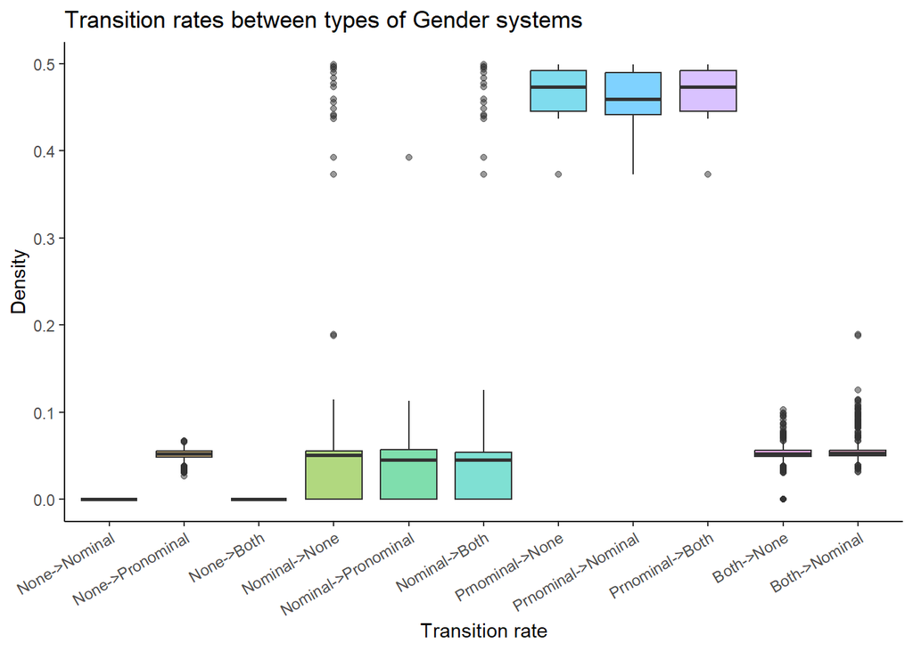

```r
gen_log<- bt_read.log('Nom_Pronom/log/world_gender_system-RJHPoutput.Log.txt')

dens_gen_sys <- select(as_tibble(gen_log), q01, q02, q03, q10, q12, q13, q20, q21, q23, q31, q31, q32) %>%
  gather() #make long format for ggplot

dens_plot_gen <- ggplot(dens_gen_sys, aes(y = value, x = key, fill = key)) +
  ylim(c(0,0.5)) +
  geom_boxplot(alpha = 0.5) +
  xlab("Transition rate") +
  ylab("Density") +
  scale_fill_discrete(name = "Transitions") +
  theme_classic() +
  theme(legend.position = c(2,0.8), axis.text.x=element_text(angle=30, hjust=1)) +
  ggtitle("Transition rates between types of Gender systems") +
  scale_x_discrete(labels = c('None->Nominal', 'None->Pronominal', 'None->Both', 'Nominal->None', 'Nominal->Pronominal', 'Nominal->Both', 'Prnominal->None', 'Prnominal->Nominal', 'Prnominal->Both', 'Both->None', 'Both->Nominal','Both->Pronominal' ))
print(dens_plot_gen)
```

# Transition rates between types of nominal gender systems

Next, we prepare the data for the phylogenetic analysis on the transition rates between the different types of gender systems: Masculine-Feminine, Masculine-Feminine-Neuter, Common-Neuter (here regarded as Masculine-Neuter). We change it to numeric values for BayesTraits: 1 = Masculine-Feminine 2 = Masculine-Feminine-Neuter 3 = Masculine-Neuter 4 = No nominal gender system

```r
ww.nom.sys <- read_excel("S3_Global_Gender.xlsx") %>%
  # only take the columns we want
  select("Glottocode", "System_nom") %>%
  rename("Gender" = "System_nom") %>%
  # assign all genders into a new gender column as 4 values of the same variable
  mutate(Gender = replace(Gender, Gender == "MF", 1)) %>%
  mutate(Gender = replace(Gender, Gender == "MFN", 2)) %>%
  mutate(Gender = replace(Gender, Gender == "MN", 3)) %>%
  mutate(Gender = replace(Gender, Gender == "NONE", 4)) %>%
  select(Glottocode,Gender) %>%
  # change to data frame
  as.data.frame() %>%
  drop_na() #remove NAs
```

We read in the phylogenetic trees and keep only the nodes for which we have data, and only keep the data that is in the trees.

```r
# only keep tip labels where we have data
trees_ww <- drop.tip.multiPhylo(trees,
                             trees[[1]]$tip.label[!trees[[1]]$tip.label %in% ww.nom.sys$Glottocode])
# only keep data for which we have the tree
data.phy.ww.nom <- ww.nom.sys %>% filter(Glottocode %in% trees_ww[[1]]$tip.label)
write_tsv(data.phy.ww.nom, "Gender_Systems/data/ww_nom_sys.txt")

# re-arrange the order of tip.labels so that they match across trees
trees_ww <- .compressTipLabel(trees_ww)
# random check that they match
all.equal(trees_ww[[1]]$tip.label, trees_ww[[5]]$tip.label)
```

```
## [1] TRUE
```

```r
writeNexus(trees_ww %>% .uncompressTipLabel(),
           "Gender_Systems/trees/trees_ww.nex")
```

Now we can run BayesTraits, with the config file found at: “/Gender_Systems/config/ww_nom_sys_config.txt”. And load the log file here to plot the results (Fig.3a).

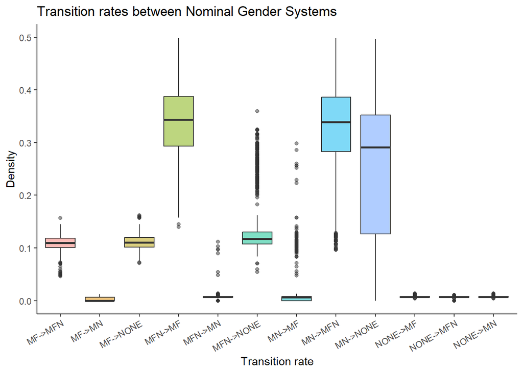

```r
ww_nom_log<- bt_read.log('Gender_Systems/log/world_nom-RJHPoutput.Log.txt')

gender_density_n <- select(as_tibble(ww_nom_log), q12, q13, q14, q21, q23, q24, q31, q32, q34, q41, q42, q43) %>%
  gather() #make long format for ggplot

dens_plot_nom <- ggplot(gender_density_n,
                           aes(y = value, x = key, fill = key)) +
  ylim(c(0,0.5)) +
  geom_boxplot(alpha = 0.5) +
  xlab("Transition rate") +
  ylab("Density") +
  scale_fill_discrete(name = "Transitions") +
  theme_classic() +
  theme(legend.position = c(2,0.8), axis.text.x=element_text(angle=30, hjust=1)) +
  ggtitle("Transition rates between Nominal Gender Systems") +
  scale_x_discrete(labels = c('MF->MFN', 'MF->MN', 'MF->NONE', 'MFN->MF', 'MFN->MN', 'MFN->NONE', 'MN->MF', 'MN->MFN', 'MN->NONE', 'NONE->MF', 'NONE->MFN', 'NONE->MN'))

print(dens_plot_nom)
```

# Lexical analysis to evaluate the hypothesis whether semantic properties play a role in the emergence of gender systems

Here we text whether the Animacy of a noun is correlated with specific genders, and whether the noun’s belonging to the Culture or Nature realm, as defined in the paper, is correlated to specific genders.

#Animacy

```r
# read the data
lex_gender <- read_excel("S4_Lexical_data_IE_Arawak.xlsx") %>%
  select("Family", "Language", "GlottoCode", "Concept", "ReplaceGender2", "Animacy", "Culture") %>%
  filter(ReplaceGender2 != "other") %>%
  mutate(ReplaceGender2 = ifelse(ReplaceGender2 == "N/I", "N", ReplaceGender2)) %>%
  rename(Gender = ReplaceGender2) %>%
  rename(Glottocode = GlottoCode) %>%
  drop_na()
```

## Animate-Inanimate

```r
lex_anim <- lex_gender %>%
  mutate(Gender = recode(Gender,
                         "C" = "Common",
                         "F" = "Feminine",
                         "M" = "Masculine",
                         "N" = "Neuter")) %>%
  mutate(Gender = factor(Gender, levels = rev(c("Masculine", "Feminine", "Neuter", "Common")))) %>%
  count(Animacy, Gender) %>%
  group_by(Animacy) %>%
  mutate(Percentage = n / sum(n)) %>%
  ungroup()

contingency_table_anim <- lex_anim %>%
  select(Animacy, Gender, n) %>%
  pivot_wider(names_from = Gender, values_from = n, values_fill = 0) %>%
  column_to_rownames("Animacy") %>%
  as.matrix()

# Run chi-square test
chisq_result_anim <- chisq.test(contingency_table_anim)
print(chisq_result_anim)
```

```
##
##  Pearson's Chi-squared test
##
## data:  contingency_table_anim
## X-squared = 959.24, df = 3, p-value < 0.00000000000000022
```

```r
# Extract standardized residuals
residuals_anim <- as.data.frame(as.table(chisq_result_anim$stdres))
colnames(residuals_anim) <- c("Animacy", "Gender", "Residual")
```

# Per family analysis

This pattern of High Animacy associated with Masculine and Common nouns and Low Animacy associated with Feminine and Neuter nouns also holds when we look at each family separately.

```r
### Arawak ###
lex_anim_ar <- lex_gender %>%
  filter(Family == "Arawak") %>%
  mutate(Gender = recode(Gender,
                         "C" = "Common",
                         "F" = "Feminine",
                         "M" = "Masculine",
                         "N" = "Neuter")) %>%
  mutate(Gender = factor(Gender, levels = rev(c("Masculine", "Feminine", "Neuter", "Common")))) %>%
  count(Animacy, Gender) %>%
  group_by(Animacy) %>%
  mutate(Percentage = n / sum(n)) %>%
  ungroup()

contingency_table_anim_ar <- lex_anim_ar %>%
  select(Animacy, Gender, n) %>%
  pivot_wider(names_from = Gender, values_from = n, values_fill = 0) %>%
  column_to_rownames("Animacy") %>%
  as.matrix()

# Run chi-square test
chisq_result_anim_ar <- chisq.test(contingency_table_anim_ar)
print(chisq_result_anim_ar)
```

```
##
##  Pearson's Chi-squared test
##
## data:  contingency_table_anim_ar
## X-squared = 831.78, df = 3, p-value < 0.00000000000000022
```

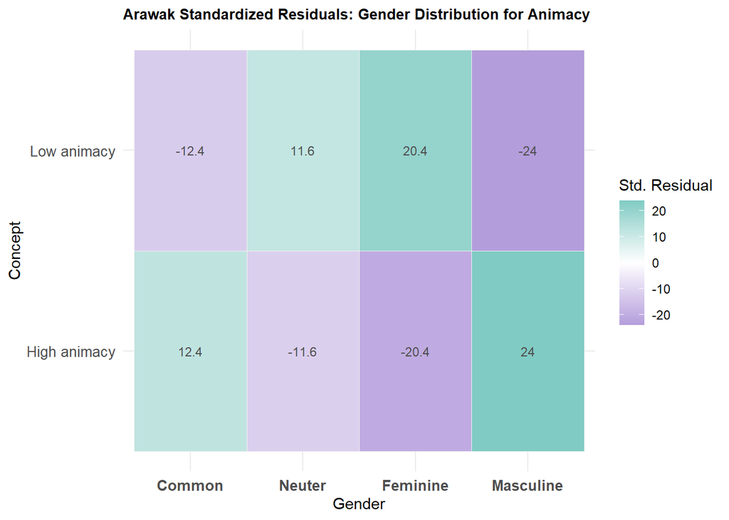

```r
# Extract standardized residuals
residuals_anim_ar <- as.data.frame(as.table(chisq_result_anim_ar$stdres))
colnames(residuals_anim_ar) <- c("Animacy", "Gender", "Residual")

# Plot standardized residuals with numbers
ggplot(residuals_anim_ar, aes(x = Gender, y = Animacy, fill = Residual)) +
  geom_tile(color = "grey95", size = 0.1) +
  geom_text(
    aes(label = round(Residual, 1)),
    size = 3, color = "gray30", family = "Georgia"
  ) +
  scale_fill_gradient2(
    low = "#b39ddb", mid = "white", high = "#80cbc4", midpoint = 0,
    name = "Std. Residual"
  ) +
  labs(
    title = "Arawak Standardized Residuals: Gender Distribution for Animacy",
    x = "Gender", y = "Concept"
  ) +
  theme_minimal(base_family = "Georgia") +
  theme(
    axis.text.x = element_text(angle = 0, hjust = 0.5, size = 10, face = "bold"),
    axis.text.y = element_text(size = 10),
    plot.title = element_text(size = 10, face = "bold"),
    legend.position = "right"
  )
```

```r
### Indo-European ###
lex_anim_ie <- lex_gender %>%
  filter(Family == "Indo-European") %>%
  mutate(Gender = recode(Gender,
                         "C" = "Common",
                         "F" = "Feminine",
                         "M" = "Masculine",
                         "N" = "Neuter")) %>%
  mutate(Gender = factor(Gender, levels = rev(c("Masculine", "Feminine", "Neuter", "Common")))) %>%
  count(Animacy, Gender) %>%
  group_by(Animacy) %>%
  mutate(Percentage = n / sum(n)) %>%
  ungroup()

contingency_table_anim_ie <- lex_anim_ie %>%
  select(Animacy, Gender, n) %>%
  pivot_wider(names_from = Gender, values_from = n, values_fill = 0) %>%
  column_to_rownames("Animacy") %>%
  as.matrix()

# Run chi-square test
chisq_result_anim_ie <- chisq.test(contingency_table_anim_ie)
print(chisq_result_anim_ie)
```

```
##
##  Pearson's Chi-squared test
##
## data:  contingency_table_anim_ie
## X-squared = 474.32, df = 3, p-value < 0.00000000000000022
```

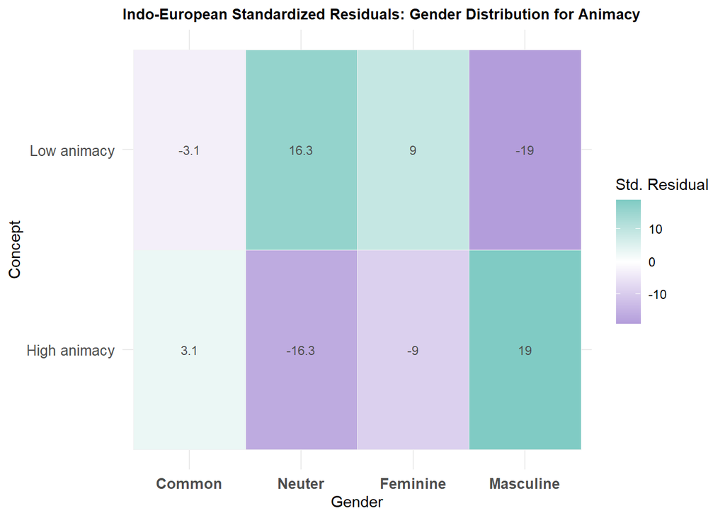

```r
# Extract standardized residuals
residuals_anim_ie <- as.data.frame(as.table(chisq_result_anim_ie$stdres))
colnames(residuals_anim_ie) <- c("Animacy", "Gender", "Residual")

# Plot standardized residuals with numbers
ggplot(residuals_anim_ie, aes(x = Gender, y = Animacy, fill = Residual)) +
  geom_tile(color = "grey95", size = 0.1) +
  geom_text(
    aes(label = round(Residual, 1)),
    size = 3, color = "gray30", family = "Georgia"
  ) +
  scale_fill_gradient2(
    low = "#b39ddb", mid = "white", high = "#80cbc4", midpoint = 0,
    name = "Std. Residual"
  ) +
  labs(
    title = "Indo-European Standardized Residuals: Gender Distribution for Animacy",
    x = "Gender", y = "Concept"
  ) +
  theme_minimal(base_family = "Georgia") +
  theme(
    axis.text.x = element_text(angle = 0, hjust = 0.5, size = 10, face = "bold"),
    axis.text.y = element_text(size = 10),
    plot.title = element_text(size = 10, face = "bold"),
    legend.position = "right"
  )
```

# Culture - Nature

```r
lex_cul_nat <- lex_gender %>%
  mutate(Gender = recode(Gender,
                         "C" = "Common",
                         "F" = "Feminine",
                         "M" = "Masculine",
                         "N" = "Neuter")) %>%
  mutate(Gender = factor(Gender, levels = rev(c("Masculine", "Feminine", "Neuter", "Common")))) %>%
  count(Culture, Gender) %>%
  group_by(Culture) %>%
  mutate(Percentage = n / sum(n)) %>%
  ungroup()

contingency_table_cul <- lex_cul_nat %>%
  select(Culture, Gender, n) %>%
  pivot_wider(names_from = Gender, values_from = n, values_fill = 0) %>%
  column_to_rownames("Culture") %>%
  as.matrix()

# Run chi-square test
chisq_result_cul <- chisq.test(contingency_table_cul)
print(chisq_result_cul)
```

```
##
##  Pearson's Chi-squared test
##
## data:  contingency_table_cul
## X-squared = 384.63, df = 3, p-value < 0.00000000000000022
```

```r
# Extract standardized residuals
residuals_cul <- as.data.frame(as.table(chisq_result_cul$stdres))
colnames(residuals_cul) <- c("Culture", "Gender", "Residual")
```

# Per family analysis

The pattern we see in the analysis of both family mainly hold for each family alone as well. Nature nouns are correlated with Masculine and Common and Culture nouns with Neuter and Feminine, though in the Indo-European family, there is no significant effect for the Feminine gender.

```r
### Arawak ###
lex_cul_nat_ar <- lex_gender %>%
  filter(Family == "Arawak") %>%
  mutate(Gender = recode(Gender,
                         "C" = "Common",
                         "F" = "Feminine",
                         "M" = "Masculine",
                         "N" = "Neuter")) %>%
  mutate(Gender = factor(Gender, levels = rev(c("Masculine", "Feminine", "Neuter", "Common")))) %>%
  count(Culture, Gender) %>%
  group_by(Culture) %>%
  mutate(Percentage = n / sum(n)) %>%
  ungroup()

contingency_table_cul_ar <- lex_cul_nat_ar %>%
  select(Culture, Gender, n) %>%
  pivot_wider(names_from = Gender, values_from = n, values_fill = 0) %>%
  column_to_rownames("Culture") %>%
  as.matrix()

# Run chi-square test
chisq_result_cul_ar <- chisq.test(contingency_table_cul_ar)
print(chisq_result_cul_ar)
```

```
##
##  Pearson's Chi-squared test
##
## data:  contingency_table_cul_ar
## X-squared = 326.91, df = 3, p-value < 0.00000000000000022
```

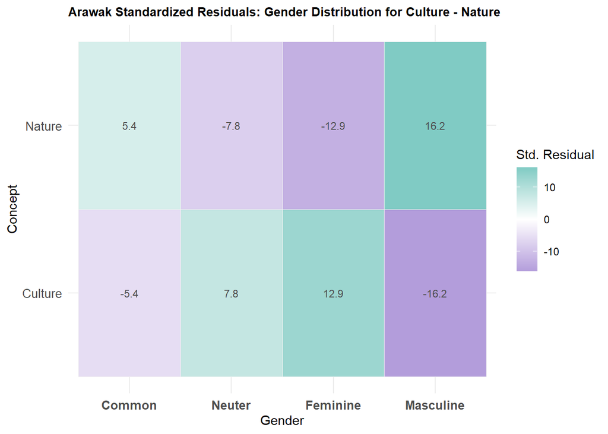

```r
# Extract standardized residuals
residuals_cul_ar <- as.data.frame(as.table(chisq_result_cul_ar$stdres))
colnames(residuals_cul_ar) <- c("Culture", "Gender", "Residual")

# Plot standardized residuals with numbers
ggplot(residuals_cul_ar, aes(x = Gender, y = Culture, fill = Residual)) +
  geom_tile(color = "grey95", size = 0.1) +
  geom_text(
    aes(label = round(Residual, 1)),
    size = 3, color = "gray30", family = "Georgia"
  ) +
  scale_fill_gradient2(
    low = "#b39ddb", mid = "white", high = "#80cbc4", midpoint = 0,
    name = "Std. Residual"
  ) +
  labs(
    title = "Arawak Standardized Residuals: Gender Distribution for Culture - Nature",
    x = "Gender", y = "Concept"
  ) +
  theme_minimal(base_family = "Georgia") +
  theme(
    axis.text.x = element_text(angle = 0, hjust = 0.5, size = 10, face = "bold"),
    axis.text.y = element_text(size = 10),
    plot.title = element_text(size = 10, face = "bold"),
    legend.position = "right"
  )
```

```r
### Indo-European ###
lex_cul_nat_ie <- lex_gender %>%
  filter(Family == "Indo-European") %>%
  mutate(Gender = recode(Gender,
                         "C" = "Common",
                         "F" = "Feminine",
                         "M" = "Masculine",
                         "N" = "Neuter")) %>%
  mutate(Gender = factor(Gender, levels = rev(c("Masculine", "Feminine", "Neuter", "Common")))) %>%
  count(Culture, Gender) %>%
  group_by(Culture) %>%
  mutate(Percentage = n / sum(n)) %>%
  ungroup()

contingency_table_cul_ie <- lex_cul_nat_ie %>%
  select(Culture, Gender, n) %>%
  pivot_wider(names_from = Gender, values_from = n, values_fill = 0) %>%
  column_to_rownames("Culture") %>%
  as.matrix()

# Run chi-square test
chisq_result_cul_ie <- chisq.test(contingency_table_cul_ie)
print(chisq_result_cul_ie)
```

```
##
##  Pearson's Chi-squared test
##
## data:  contingency_table_cul_ie
## X-squared = 235.59, df = 3, p-value < 0.00000000000000022
```

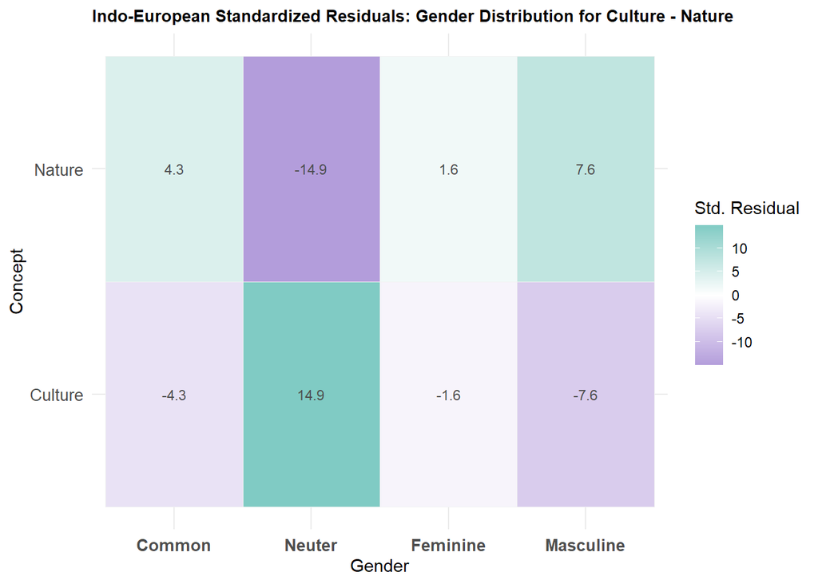

```r
# Extract standardized residuals
residuals_cul_ie <- as.data.frame(as.table(chisq_result_cul_ie$stdres))
colnames(residuals_cul_ie) <- c("Culture", "Gender", "Residual")

# Plot standardized residuals with numbers
ggplot(residuals_cul_ie, aes(x = Gender, y = Culture, fill = Residual)) +
  geom_tile(color = "grey95", size = 0.1) +
  geom_text(
    aes(label = round(Residual, 1)),
    size = 3, color = "gray30", family = "Georgia"
  ) +
  scale_fill_gradient2(
    low = "#b39ddb", mid = "white", high = "#80cbc4", midpoint = 0,
    name = "Std. Residual"
  ) +
  labs(
    title = "Indo-European Standardized Residuals: Gender Distribution for Culture - Nature",
    x = "Gender", y = "Concept"
  ) +
  theme_minimal(base_family = "Georgia") +
  theme(
    axis.text.x = element_text(angle = 0, hjust = 0.5, size = 10, face = "bold"),
    axis.text.y = element_text(size = 10),
    plot.title = element_text(size = 10, face = "bold"),
    legend.position = "right"
  )
```

Plot both Animacy and Culture together for paper:

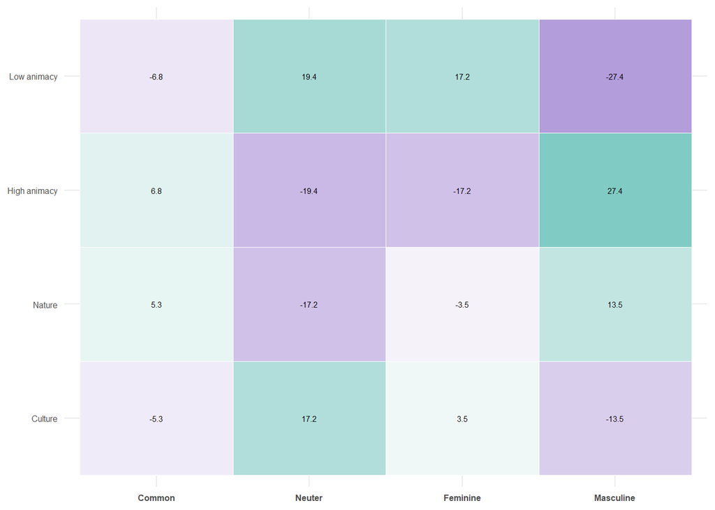

```r
# Standardize and add Category column
residuals_anim <- residuals_anim %>%
  rename(Dimension = Animacy) %>%
  mutate(Category = Dimension) %>%   # Store original Animacy value
  select(Category, Gender, Residual, Dimension)

residuals_cul <- residuals_cul %>%
  rename(Dimension = Culture) %>%
  mutate(Category = Dimension) %>%   # Store original Culture value
  select(Category, Gender, Residual, Dimension)

residuals_both <- bind_rows(residuals_cul, residuals_anim)

ggplot(residuals_both, aes(x = Gender, y = Category, fill = Residual)) +
  geom_tile(color = "white") +
  geom_text(aes(label = round(Residual, 1)), size = 2, color = "black") +
  scale_fill_gradient2(
    low = "#b39ddb", mid = "white", high = "#80cbc4", midpoint = 0,
    name = "Std. Residual"
  ) +
  theme_minimal(base_family = "Georgia") +
  theme(
    axis.title = element_blank(),
    axis.text.x = element_text(size = 6, face = "bold"),
    axis.text.y = element_text(size = 6),
    axis.ticks = element_blank(),
     legend.position = "none"
  )
```

```r
ggsave("figure4.png", width = 6, height = 2, dpi = 300)
```